# 02_Client_Server_Interaction

## Взаємодія клієнта та сервера.

Взаємодія клієнта та сервера є ключовим аспектом в розробці та функціонуванні багатьох інформаційних систем та Web-додатків. **Основні концепції цієї взаємодії визначають яким чином відбувається обмін даними** між клієнтом (зазвичай це кінцевий користувач) та сервером (де знаходиться цільовий ресурс чи сервіс).

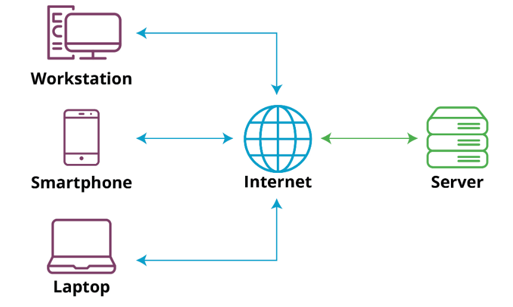

**Деякі ключові концепції взаємодії клієнта та сервера.**

**Протоколи комунікації:**

- **HTTP (Hypertext Transfer Protocol).** Основний протокол для передачі гіпертекстових даних в інтернеті. Зазвичай використовується для передачі Web-сторінок.
- **HTTPS (Hypertext Transfer Protocol Secure).** Забезпечує шифрування даних для безпечної комунікації через інтернет.

**Client-Server архітектурний стиль.** Модель, в якій клієнт та сервер є розділеними сутностями, що взаємодіють одна з одною через мережу. Сервер надає ресурси або послуги, а клієнт запитує ці ресурси чи послуги.

**Запит (Request) та Відповідь (Response).** Клієнт надсилає запити серверу, запитуючи певні ресурси чи послуги. Сервер обробляє ці запити і відправляє відповіді, які містять необхідні дані чи результати операцій.

**REST (Representational State Transfer)** - архітектурний стиль, який використовує HTTP для передачі та обміну даними. Взаємодія між клієнтом та сервером відбувається через стандартні HTTP-методи, такі як GET, POST, PUT, DELETE.

**API (Application Programming Interface)** - спосіб, за допомогою якого програми можуть взаємодіяти одна з одною. В інтернет-контексті API визначає, які запити та відповіді приймає та надсилає сервер.

**Сесії та Стан.** Сесії - механізм для зберігання стану між послідовними запитами того самого клієнта до сервера. Стан - інформація про стан клієнта чи сервера, яка може бути збережена та передана між ними.

**Асинхронність** - можливість взаємодії без очікування завершення операцій. Це дозволяє оптимізувати продуктивність та відповідати на багато користувацьких запитів одночасно.

**Безпека.** Захист від несанкціонованого доступу та надання конфіденційності та цілісності даних шляхом використання шифрування та інших методів.

Ці концепції формують основу ефективної взаємодії між клієнтом та сервером, забезпечуючи безперервний обмін інформацією.

**Web-сайти (Web-сторінки) можуть бути статичними та динамічними.**

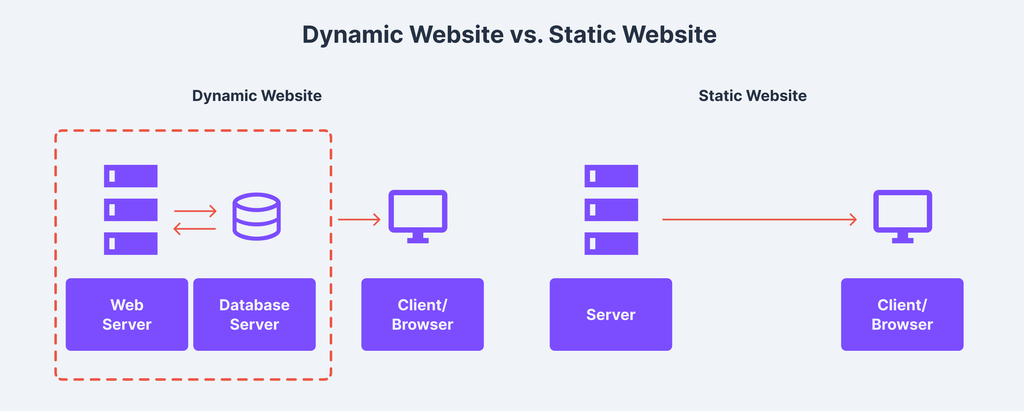

Обробка статичної Web-сторінки:

- Вводиться в адресному рядку запит або адреса сторінки.
- Браузер надсилає запит на сервер.
- Сервер аналізує запит, перевіряє наявність особливих ознак та інструкцій.
- Сервер надсилає Web-сторінку браузеру без зміни.

[Static sites.](https://developer.mozilla.org/en-US/docs/Learn/Server-side/First_steps/Client-Server_overview#static_sites)

Обробка динамічної Web-сторінки:

- Браузер надсилає запит на сервер. Наприклад, запит свідчить, що потрібно показувати певну інформацію, отже сторінка буде динамічною.
- Сервер дає запит на сервер додатків, де спеціальне програмне забезпечення застосує правила та інструкції для додавання особливих змінних. Наприклад, система авторизації, щоб показати релевантну інформацію.
- Сервер забирає готову Web-сторінку, віддає браузеру для показу.

[Dynamic sites.](https://developer.mozilla.org/en-US/docs/Learn/Server-side/First_steps/Client-Server_overview#dynamic_sites)